# Bayesian Computation with R

#### This notebook was made with ‘Bayesian Computation with R’ by Jim Albert as reference. This notebook is for personal use only.

# Ch.2 Introduction to Bayesian Thinking

#### In this chapter, the basic element of the Bayesain inferential approach are introduced through the basic problem of learning about a population proportion.

#### Before taking data, one has *beliefs* about the value of the proportion and one models his or her beliefs in terms of a *prior distribution*. We will illustrate the use of different functional forms for this prior. After data have been observed, one *updates one’s beliefs* about the proportion by computing the *posterior distribution*. Also, one may be interested in predicting the likely outcomes of a new sample taken from the population.

## Learning about the proportion of heavy sleepers

#### Suppose a person is interested in learning about the sleeping habits of American college students. she hears that doctors recommend eight hours of sleep for an average adult. What proportion of college students get at least eight hours of sleep?

#### Here we think of a population consisting of all American college students and let $p$ represent the proportion of this population who sleep (on a typical night during the week) at least eight hours. We are interested in learning about the *location* of $p$.

#### The value of the proportion $p$ is unknown. In the Bayesian viewpoint, a person’s belief about the uncertainty in this proportion are represented by a probability distribution placed on this parameter. This distribution reflects the person’s subjective prior opinion about plausible values of $p$.

#### A random sample of students from a particular university will be taken to learn about this proportion. But first the researcher does some initial research to learn about the sleeping habits of college students. This research will help her in constructing a *prior distribution*.

#### After some initial research, she believes that college students generally get less than eight hours of sleep and so $p$ is likely smaller than *0.5*. After some reflection, her best guess at the value of $p$ is *0.3*. But it is very plausible that this proportion could be any value in the interval from *0* to *0.5*.

#### A sample of *27* students is taken – in this group, *11* record that they had at least eight hours of sleep the previous night. Based on the prior information and these observed data, the researcher is intersted in *estimating* the proportion of $p$. In addition, she is interested in *predicting* the number of students that get at least eight hours of sleep if a new sample of *20* students is taken.

#### Suppose that our *prior density* for $p$ is denoted by $g(p)$. If we regard a “success” as sleeping at least eight hours and we take a random sample with $s$ successes and $\mathrm{f}$ failures, then *the likelihood function*, $L(p)$, is given by

$$L(p) \propto p^{s}(1-p)^{\mathrm{f}}, \enspace 0 < p < 1.$$

#### (Recall that the likelihood function for a binomial density is given by a $beta(s+1, \mathrm{f}+1)$. Also, note that, $L(p) = g(data|p)$).

#### The *posterior density* for $p$, $g(p|data)$, by Bayes’ rule is obtained up to a proportionality constant by multiplying the prior density by the likelihood:

$$g(p|data) \propto g(p)L(p).$$

#### We demonstrate the posterior distribution calculations using three different choices of the prior density $g$ corresponding to three models for representing the researcher’s prior knowledge about the proportion.

## Using a *Discrete* prior

#### A simple approach for assessing a prior for $p$ is to write down a list of plausible proportion values and then assign weights to these values. The person in our example believes that

$$0.05, 0.15, 0.25, 0.35, 0.45, 0.55, 0.65, 0.75, 0.85, 0.95$$

#### are possible values for $p$. Based on her beliefs, she assigns these values the corresponding *weights*

$$1, 5.2, 8, 7.2, 4.6, 2.1, 0.7, 0.1, 0, 0$$

#### which can be *converted to prior probabilities* by dividing each weight by the sum.

#### In R, we define *p* to be the vector of proportion values and *prior* the vector of corresponding weights that we normalize to probabilities. (Recall that, a probability distribution function is said to be *“normalized” if the sum of all its possible results is equal to one*).

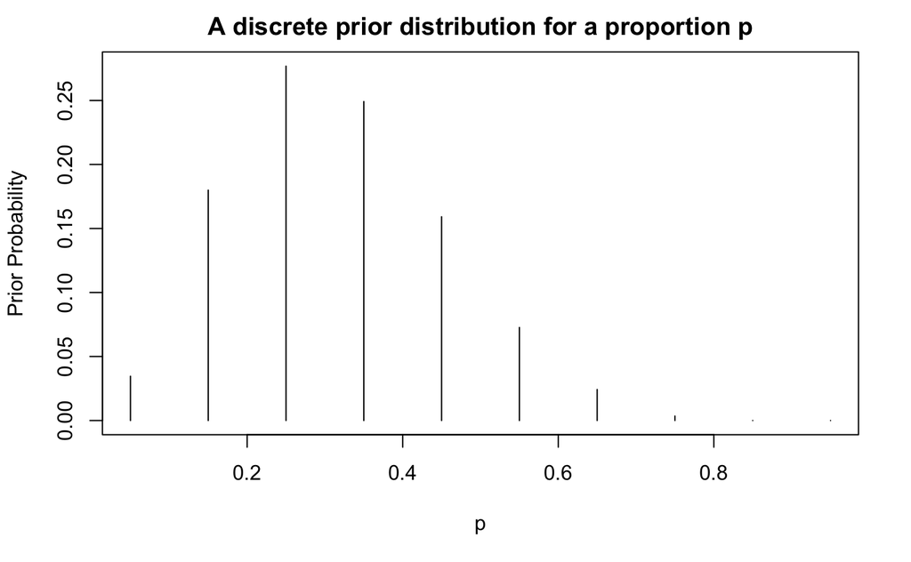

```r
p <- seq(0.05, 0.95, by=0.1)
prior <- c(1, 5.2, 8, 7.2, 4.6, 2.1, 0.7, 0.1, 0, 0)
prior <- prior/sum(prior)  # normalizing
plot(p, prior, type="h", ylab="Prior Probability", main="A discrete prior distribution for a proportion p")
```

#### In our example, *11* of *27* students sleep a sufficient number of hours, so $s$ = *11* and $\mathrm{f}$ = *16*, and the likelihood function is

$$L(p) \propto p^{11}(1-p)^{16}, \enspace 0 < p < 1.$$

#### (Note that the likelihood is a beta density with parameters $s$ + *1* = *12* and $\mathrm{f}$ + *1* = *17*).

#### The R function pdisc() in the package *LearnBayes* computes the posterior probabilities. To use pdisc(), one inputs the vector of proportion values *p*, the vector of prior probabilities *prior*, and a data vector *data* consisting of $s$ and $\mathrm{f}$. The output of a pdisc() is a vector of posterior probabilities.

```r
library(LearnBayes)  # for pdisc()
data <- c(11, 16)  # s=11, f=16
post <- pdisc(p, prior, data)
round(cbind(p, prior, post), 2)  # To display a table
```

```
         p prior post
 [1,] 0.05  0.03 0.00
 [2,] 0.15  0.18 0.00
 [3,] 0.25  0.28 0.13
 [4,] 0.35  0.25 0.48
 [5,] 0.45  0.16 0.33
 [6,] 0.55  0.07 0.06
 [7,] 0.65  0.02 0.00
 [8,] 0.75  0.00 0.00
 [9,] 0.85  0.00 0.00
[10,] 0.95  0.00 0.00
```

#### The xyplot() function in the *lattice* package is used to construct comparative line graphs of the prior and posterior distributions.

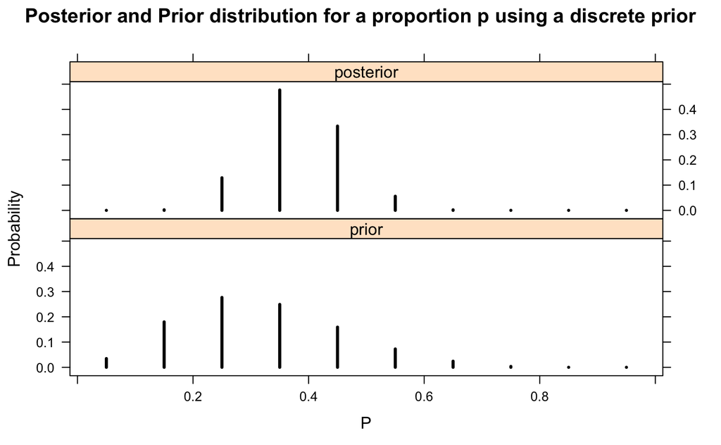

```r
library(lattice)
PRIOR <- data.frame("prior", p, prior)
POST <- data.frame("posterior", p, post)
names(PRIOR) <- c("Type", "P", "Probability")
names(POST) <- c("Type", "P", "Probability")
data <- rbind(PRIOR, POST)
xyplot(Probability~P|Type, data=data, layout=c(1,2), type="h", lwd=3, col="black", main="Posterior and Prior distribution for a proportion p using a discrete prior")
```

#### Here we note that most of the posterior probability is concentrated on the values $p$ = *0.35* and $p$ = *0.45*. If we combine the probabilities for the three most likely values, we can say the posterior probability that $p$ falls in the set *{0.25, 0.35, 0.45}* is equal to *0.13 + 0.48 + 0.33 = 0.94*.

## Using a *Beta* prior

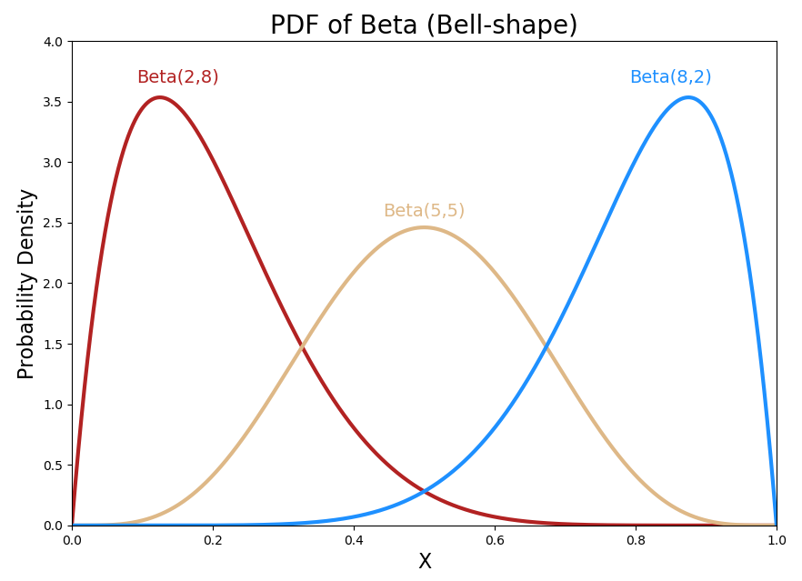

#### Since the proportion is a continuous parameter, an alternative approach is to construct a density $g(p)$ on the interval *(0, 1)* that represents the person’s initial beliefs.

#### Suppose she believes that the proportion is equally likely to be smaller or larger than $p$ = *0.3*. Morover, she is *90%* confident that $p$ is less than *0.5*. A convenient family of densities for a proportion is the *beta* with *kernel proportional to*

$$g(p) \propto p^{a-1}(p-1)^{b-1}, \enspace 0 < p < 1.$$

#### where the *hyperparameters* $a$ and $b$ are chosen to reflect the user’s prior beliefs about $p$.

#### The mean of a beta prior, $m = a/(a+b)$ and the variance of the prior, $v = m(1-m)/(a+b+1)$ but it is *difficult* in practice for a user to assess values of $m$ and $v$ *to obtain values of the beta parameters* $a$ and $b$. It is *easier* to obtain $a$ and $b$ *indirectly through statements about the percentiles of the distribution*.

#### Here the person believes that the *median* and *90th percentiles* of the proportion are given, respectively, by *0.3* and *0.5*.

#### The function beta.select() in the *LearnBayes* package is useful for finding the shape parameters of the beta density that match this prior knowledge. The inputs to beta.select() are two lists, *quantile1* and *quantile2*, that defines these two prior percentiles, and the function returns the values of the matching beta parameters.

```r
quantile1 <- list(p=0.5, x=0.3)  # the median
quantile2 <- list(p=0.9, x=0.5)  # the 90th percentile
beta.select(quantile1, quantile2)
```

```
[1] 3.26 7.19
```

#### We see that this prior information is matched with a beta density with $a$ = 3.26 and $b$ = 7.19.

#### Combining this beta prior with the likelihood function, one can show that the posterior density is also of the beta form with updated parameters $a + s$ and $b + \mathrm{f}$.

$$g(p) \propto p^{a+s-1}(1-p)^{b+\mathrm{f}-1}, \enspace 0 < p < 1.$$

#### where $a + s$ = *3.26 + 11* and $b + \mathrm{f}$ = *7.19 + 16* (this is an example of *conjugate analysis*, where the prior and posterior densities have the same functional form; this means that we expect the posterior distribution to be the same distribution as prior with different parameters).

#### Since the prior, likelihood, and posterior are all in the beta family, we can use the R command dbeta() to compute the values of prior, likelihood, and posterior.

```r
# parameters for the prior
a <- 3.26
b <- 7.19
# parameters for the likelihood
s <- 11
f <- 16
curve(dbeta(x,a+s,b+f), from=0, to=1, xlab="p", ylab="Density", lty=1, col=1, lwd=2)  # The posterior
curve(dbeta(x,s+1,f+1), add=T, lty=2, col=2, lwd=2)  # The likelihood
```

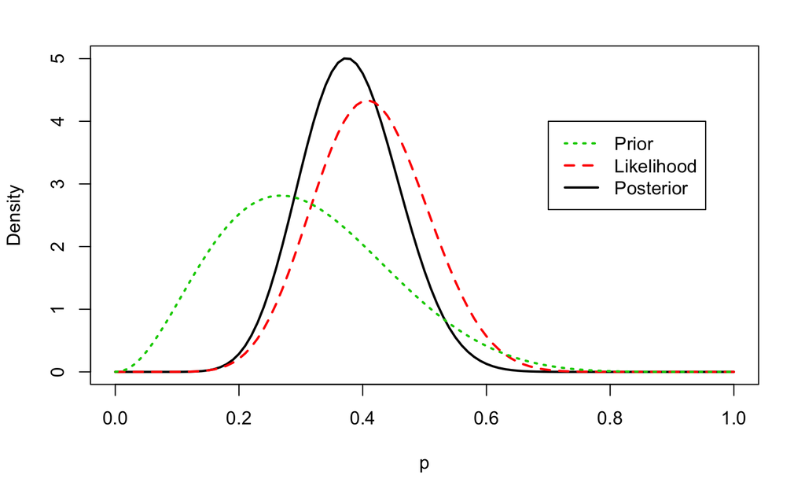

```r
curve(dbeta(x,a,b), add=T, lty=3, col=3, lwd=2)  # The prior
legend(0.7, 4, c("Prior", "Likelihood", "Posterior"), lty=c(3,2,1), col=c(3,2,1), lwd=c(2,2,2))
```

#### We can see the three densities displayed using three applications of the curve() function. This figure helps show that the *posterior density* in this case *compromises* between the initial prior beliefs and the information in the data.

### Inference by the posterior distribution based on *exact* values

#### We illustrate different ways of *summarizing the beta posterior distribution to make inferences* about the proportion of heavy sleepers $p$. The beta cdf function, pbeta(), and inverse cdf function, qbeta(), are useful in computing probabilities and constructing interval estimates for $p$. (Recall that cdf is $F(x) = P(X \leq x)$)

#### Is it likely that the proportion of heavy sleepers is greater than *0.5*? This is answered by computing the *posterior probability*

$$P(p \geq 0.5|data)$$

#### which is given by pbeta() function:

```r
1-pbeta(0.5, a+s, b+f)
```

```
[1] 0.0690226
```

#### This probability is small, so it is unlikely that more than half of the students are heavy sleepers.

#### A *90%* interval estimate for $p$ is found by computing the *5th* and *95th* percentiles of the beta density using qbeta() function:

```r
round(qbeta(c(0.05, 0.95), a+s, b+f),3)
```

```
[1] 0.256 0.513
```

#### This is the *90%* *posterior credible interval* for the proportion $p$.

#### These summaries are *exact* because they are based on R functions for the beta posterior density. An alternative method of summarization of posterior distribution is based on *simulation*.

### Inference by the posterior distribution based on *simulation*

#### In this case, we can simulate a large number of values from the beta posterior density and *summarize the simulated output*. Using the random beta command rbeta(), we simulate *1000* random proportion values from the $beta(a+s, b+\mathrm{f})$ posterior and display the posterior as a histogram of the simulated values.

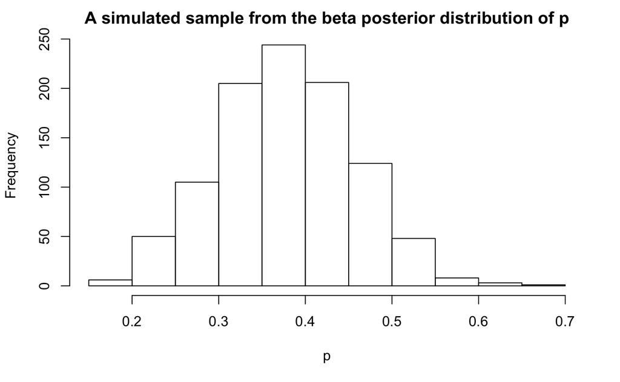

```r
ps <- rbeta(1000, a+s, b+f)  # simulated sample with 1000 values
hist(ps, xlab="p", main="A simulated sample from the beta posterior distribution of p")
```

#### The probability that the proportion is larger than *0.5* is estimated using the *proportion of simulated values in this range*.

```r
sum(ps >= 0.5)/1000  # dividing it by the total number of samples to obtain the probability
```

```
[1] 0.06
```

#### This probability based on simulation is small, so it is unlikely that more than half of the students are heavy sleepers.

#### A *90%* interval estimate can be estimated by the *5th* and *95th* *sample quantiles* of the simulated sample.

```r
quantile(ps, c(0.05, 0.95))
```

```
       5%       95%
0.2489239 0.5054705
```

#### This is the *90%* *posterior credible interval* based on simulation for the proportion $p$.

#### Note that these summaries of the posterior density for $p$ *based on simulation are approximately equal to the exact values* based on calculations from the beta distribution.

## Using a *Histogram* prior

#### Although there are computational advantages to using a beta prior, it is straightforward to perform posterior computations for *any* choice of prior.

#### We outline a *“brute-force”* method of summarizing posterior computations for an arbitrary prior density $g(p)$:

#### • Choose a grid of values of $p$ over an interval that covers the posterior density.

#### • Compute the product of the likelihood $L(p)$ and the prior $g(p)$ on the grid.

#### • Normalize by dividing each product by the sum of the products. In this step, we are approximating the posterior density by a discrete probability distribution on the grid.

#### • Using the R command sample(), take a random sample with replacement from the discrete distribution.

#### The resulting simulated draws are an *approximate sample from the posterior distribution*.

#### We illustrate this “brute-force” algorithm for a *“histogram”* prior that may better reflect the person’s prior opinion about the proportion $p$. Suppose it is convenient for our person to state her prior beliefs about the proportion of heavy sleepers by dividing the range of $p$ into ten subintervals,

$$(0,\,0.1), (0.1,\,0.2), \, ... \,, (0.9,\,1)$$

#### and then assigning probabilities to the intervals. The person in our example assigns the weights

$$1, 5.2, 8, 7.2, 4.6, 2.1, 0.7, 0.1, 0, 0$$

#### to these intervals – this can be viewed as a continuous version of the discrete prior earlier.

#### In R, we represent this histogram prior with the vector *midpt*, which contains the *midpoints of the intervals*, and the vector *prior*, which contains the *associated prior weights*. We *convert the prior weights to probabilities* by dividing each weight by the sum. We graph this prior using curve() and histprior() in the *LearnBayes* package.

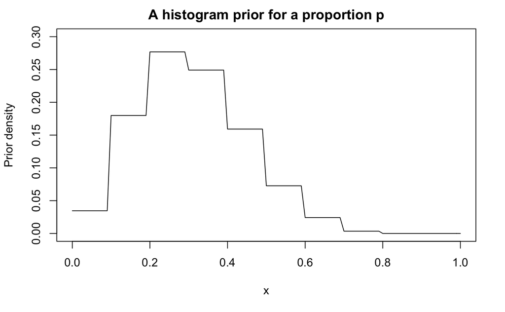

```r
midpt <- seq(0.05, 0.95, by=0.1)  # the midpoints of the intervals
prior <- c(1, 5.2, 8, 7.2, 4.6, 2.1, 0.7, 0.1, 0, 0)  # the prior weights
prior <- prior/sum(prior)  # normalizing to obtain the probabilities
curve(histprior(x, midpt, prior), from=0, to=1, ylab="Prior density", ylim=c(0,0.3), main="A histogram prior for a proportion p")
```

#### We compute the posterior density by *multiplying the histogram prior by the likelihood function*. (Recall that the likelihood function for a binomial density is given by a $beta(s+1, \mathrm{f}+1)$); this function is available using dbeta() function).

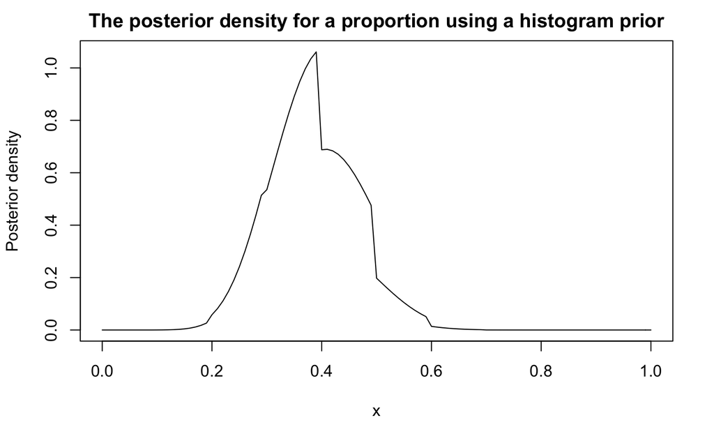

```r
curve(histprior(x, midpt, prior)*dbeta(x, s+1, f+1),  # computing the product to obtain the posterior
      from=0, to=1, ylab="Posterior density", main="The posterior density for a proportion using a histogram prior")
```

#### To obtain a simulated sample from the posterior density by our algorithm, we first construct an *equally spaced grid of values* of the proportion *p* and *compute the product* of the prior and likelihood on this grid. Then we *normalize* the products on the grid to probabilities.

```r
p <- seq(0, 1, length=500)  # equally spaced grid of values of the proportion
post <- histprior(p, midpt, prior)*dbeta(p, s+1, f+1)  # computing the product to obtain the posterior
post <- post/sum(post)  # normalizing the grid to obtain the probabilities
```

#### Last, we take a *sample with replacement* from the grid using the sample() function.

```r
ps <- sample(p, replace=T, prob=post)
```

#### We can then plot a histogram of the simulated values.

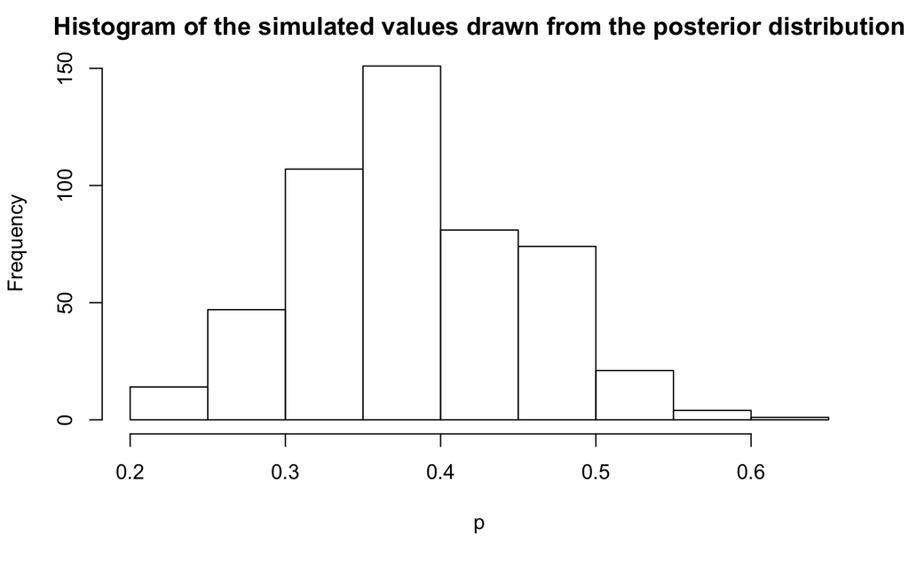

```r
hist(ps, xlab="p", main="Histogram of the simulated values drawn from the posterior distribution")
```

#### The simulated draws can be used as before to *summarize* any feature of the posterior distribution of interest to *make inference*.

## Prediction

#### We have focused on learning about the population proportion of heavy sleepers $p$. Suppose our person is also interested in predicting the number of heavy sleepers $\tilde{y}$ in a future sample of $m$ = *20* students. If the *current beliefs* about $p$ are contained in the density $g(p)$, then the *predictive density* of $\tilde{y}$ is given by

$$f(\tilde{y}) = \int f(\tilde{y}|p)g(p)dp.$$

#### If $g$ is a prior density, then we refer to this as the *prior* predictive density, and if $g$ is a posterior, then $f$ is a *posterior* predictive density.

#### We illustrate the computation of the predictive density using the different forms of prior density described in this chapter.

### Using a *Discrete* prior

#### Suppose we use a *discrete* prior where $\left \{ p_{i} \right \}$ represent the possible values of the proportion with respective probabilities $\left \{ g(p_{i}) \right \}$. Let $f_{B}(y|n,p)$ denote the *binomial sampling density* given values of the sample size $n$ and proportion $p$:

$$f_{B}(y|n,p) = \binom{n}{y} p^{y} (1-p)^{n-y}, \enspace y = 0, \cdots, n.$$

#### Then the predictive probability of $\tilde{y}$ successes in a future sample of size $m$ is given by

$$f(\tilde{y}) = \sum f_{B}(\tilde{y}|m,p_{i})g(p_{i}).$$

#### The function pdiscp() in the *LearnBayes* package can be used to compute the predictive probabilities when $p$ is given a discrete distribution. As before, *p* is a vector of proportion values and *prior* a vector of current probabilities. The remaining arguments are the future sample size *m* and a vector *y_tildes* of numbers of successes of interest. The output is a vector of the corresponding predictive probabilities.

```r
library(LearnBayes)  # for pdiscp()
p <- seq(0.05, 0.95, by=0.1)  # a vector of proportion values
prior <- c(1, 5.2, 8, 7.2, 4.6, 2.1, 0.7, 0.1, 0, 0)  # a vector of current weights
prior <- prior/sum(prior)  # normalizing to obtain probabilities
m <- 20  # future sample size
y_tildes <- 0:20  # a vector of numbers of successes of interest
pred <- pdiscp(p, prior, m, y_tildes)
round(cbind(0:20,pred), 3)
```

```
          pred
 [1,]  0 0.020
 [2,]  1 0.044
 [3,]  2 0.069
 [4,]  3 0.092
 [5,]  4 0.106
 [6,]  5 0.112
 [7,]  6 0.110
 [8,]  7 0.102
 [9,]  8 0.089
[10,]  9 0.074
[11,] 10 0.059
[12,] 11 0.044
[13,] 12 0.031
[14,] 13 0.021
[15,] 14 0.013
[16,] 15 0.007
[17,] 16 0.004
[18,] 17 0.002
[19,] 18 0.001
[20,] 19 0.000
[21,] 20 0.000
```

#### We see from the output that the most likely number of successes in this future sample are $\tilde{y}$ = *5* and $\tilde{y}$ = *6*.

### Using a *Beta* prior

#### Suppose instead that we model our beliefs about $p$ using a $beta(a,b)$ prior. In this case, we can analytically integrate out $p$ to get a closed-form expression for the predictive density,

$$\begin{aligned}
f(\tilde{y}) &= \int f_{B}(\tilde{y}|m,p)g(p)dp \\
&= \binom{m}{\tilde{y}}\frac{B(a + \tilde{y}, b + m - \tilde{y})}{B(a,b)}, \enspace \tilde{y} = 0, \cdots, m,
\end{aligned}$$

#### Where $B(a,b)$ is the beta function.

#### The predictive probabilities using the beta density are computed using the function pbetap(). The inputs to this function are the vector *ab* of beta parameters, $a$ and $b$, the size of the future sample *m*, and the vector of numbers of successes *y_tildes*. The output is a vector of predictive probabilities corresponding to the values in $\tilde{y}$.

#### We illustrate this computation using the $beta(3.26, 7.19)$ prior used to reflect the person’s beliefs about the proportion of heavy sleepers at the school.

```r
ab <- c(3.26, 7.19)  # vector of beta parameters a and b
m <- 20  # future sample size
y_tildes <- 0:20  # vector of numbers of successess y_tilde
pred <- pbetap(ab, m, y_tildes)
pred
```

```
 [1] 1.812205e-02 4.511485e-02 7.248106e-02 9.456396e-02 1.084896e-01 1.135841e-01 1.106895e-01
 [8] 1.015339e-01 8.821389e-02 7.280839e-02 5.712007e-02 4.252974e-02 2.994441e-02 1.981684e-02
[15] 1.221463e-02 6.917948e-03 3.527752e-03 1.568885e-03 5.764529e-04 1.575142e-04 2.438293e-05
```

### Using *Any* prior

#### We have illustrated the computation of the predictive density for two choices of prior densities. One convenient way of computing a predictive density for *any* prior is by *simulation*. To obtain $\tilde{y}$, we first simulate, say, $p^{*}$ from $g(p)$, and then simulate $\tilde{y}$ from the binomial distribution $f_{B}(\tilde{y}|p^{*})$.

#### We demonstrate this simulation approach for the $beta(3.26,7.19)$ prior. We first simulate *1000* draws from the prior and store the simulated values in a vector, *p*:

```r
p <- rbeta(1000, 3.26, 7.19)
```

#### Then we simulate values of $\tilde{y}$ for these random values (*probabilities*) inside the vector *p* using the rbinom() function.

```r
y_tilde <- rbinom(1000, 20, p)
```

#### To *summarize* the simulated draws of $\tilde{y}$, we first use the table() function to tabulate the distinct values; we count the frequencies of each $\tilde{y}$ value.

```r
table(y_tilde)
```

```
y_tilde
  0   1   2   3   4   5   6   7   8   9  10  11  12  13  14  15  16
 22  40  84 106 104 113 115 101  83  75  53  34  32  14  14   9   1
```

#### The reason why there is no *17, 18, 19, 20* is because their frequencies are *0*.

```r
sum(y_tilde == 17); sum(y_tilde == 18); sum(y_tilde == 19); sum(y_tilde == 20)
```

```
[1] 0
[1] 0
[1] 0
[1] 0
```

#### We save the frequencies of $\tilde{y}$ in a vector *freq*. Then we *normalize* the frequencies to probabilities by dividing each frequency by the sum and use the plot() command to graph the predictive distribution.

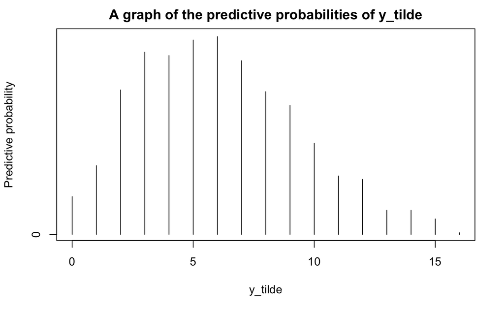

```r
freq <- table(y_tilde)  # saving the frequencies of each number of y_tilde
y_tildes <- as.integer(names(freq))  # a vector of each number of y_tilde
predprob <- freq/sum(freq)  # normalizing the frequencies to obtain probabilities
plot(y_tildes, predprob, type="h", xlab="y_tilde", ylab="Predictive probability", main="A graph of the predictive probabilities of y_tilde")
```

#### Suppose we wish to summarize this discrete predictive distribution by an interval that covers at least *90%* of the probability. The R function discint() in the *LearnBayes* package is useful for this purpose. In the output, the vector *y_tildes* contains the values of $\tilde{y}$ and *predprob* contains the associated probabilities found from the table output. The matrix *dist* contains the probability with the columns *y_tildes* and *predprob*.

```r
dist <- cbind(y_tildes, predprob)
dist
```

```
   y_tildes predprob
0         0    0.022
1         1    0.040
2         2    0.084
3         3    0.106
4         4    0.104
5         5    0.113
6         6    0.115
7         7    0.101
8         8    0.083
9         9    0.075
10       10    0.053
11       11    0.034
12       12    0.032
13       13    0.014
14       14    0.014
15       15    0.009
16       16    0.001
```

#### The function discint() has two inputs: the matrix *dist* and a given coverage probability *covprob* (since we wish to get an interval that covers at least 90% of the probability, we set *covprob* to *0.9*). The output is a list where the component *set* gives the credible set and *prob* gives the exact coverage probability.

```r
covprob <- 0.9  # since we wish to get an interval that covers at least 90% of the probability
discint(dist, covprob)
```

```
$prob
   11
0.908

$set
 1  2  3  4  5  6  7  8  9 10 11
 1  2  3  4  5  6  7  8  9 10 11
```

#### We see that the probability that $\tilde{y}$ falls in the interval *{1, 2, 3, 4, 5, 6, 7, 8, 9, 10, 11}* is *90.8%*. To say it in a different way, let $\tilde{y}$/*20* denote the proportion of sleepers in the future sample. The probability that this sample proportion falls in the interval *[1/20, 11/20] = [0.05, 0.55]* is *90.8%*.

#### As expected, this interval is much wider than a *90.8%* probability interval for the population proportion $p$ (we previously saw that the *90% posterior credible interval* was around *[0.25, 0.51]*). In predicting a future sample proportion, there are *two sources of uncertainty* – the uncertainty in the value of $p$ and the binomial uncertainty in the value of $\tilde{y}$. Therefore, the *predictive interval is relatively long* since it incorporates both types of uncertainty.

## Summary of R Functions

**beta.select()** – finds the shape parameters of a beta density that matches knowledge of two quantiles of the distribution

*Usage*: beta.select(quantile1,quantile2)

*Arguments*: quantile1, list with components p, the value of the first probability, and x, the value of the first quantile; quantile2, list with components p, the value of the second probability, and x, the value of the second quantile

*Value*: vector of shape parameters of the matching beta distribution

**discint()** – computes a highest probability interval for a discrete distribution

*Usage*: discint(dist,prob)

*Arguments*: dist, a probability distribution written as a matrix, where the first column contains the values and the second column contains the probabilities; prob, the probability content of interest

*Value*: prob, the exact probability content of the interval, and set, the set of values of the probability interval

**histprior()** – computes the density of a probability distribution defined on a set of equal-width intervals

*Usage*: histprior(p,midpts,prob)

*Arguments*: p, the vector of values for which the density is to be computed; midpts, the vector of midpoints of the intervals; prob, the vector of probabilities of the intervals

*Value*: vector of values of the probability density

**pbetap()** – computes the predictive distribution for the number of successes of a future binomial experiment with a beta distribution for the proportion

*Usage*: pbetap(ab, n, s)

*Arguments*: ab, the vector of parameters of the beta prior; n, the size of the future binomial sample; s, the vector of the numbers of successes for a future binomial experiment

*Value*: the vector of predictive probabilities for the values in the vector s

**pdisc()** – computes the posterior distribution for a proportion for a discrete prior distribution

*Usage*: pdisc(p, prior, data)

*Arguments*: p, a vector of proportion values; prior, a vector of prior probabilities; data, a vector consisting of the number of successes and number of failures

*Value*: the vector of posterior probabilities

**pdiscp()** – computes the predictive distribution for the number of successes of a future binomial experiment with a discrete distribution for the proportion

*Usage*: pdiscp(p, probs, n, s)

*Arguments*: p, the vector of proportion values; probs, the vector of probabilities; n, the size of the future binomial sample; s, the vector of the numbers of successes for a future binomial experiment

*Value*: the vector of predictive probabilities for the values in the vector s